# Econ. Rodrigo H. Ozon: Portfólio de Projetos

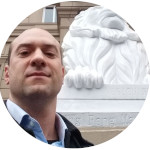

$$\widehat{Y}_{t+n}=\mbox{(Only God knows)}+0\epsilon$$

*Where:*

(Only God Knows) $=$ Jr 29:11

$0\epsilon=$ he is omniscient, omnipresent and omnipotent

**Conteúdo**

- Apresentação pessoal
- Cargos e serviços prestados
- Entregas e projetos por onde atuei
- Meus profiles
- Formação Acadêmica, habilidades e know how

## Apresentação pessoal

*Rodrigo Hermont Ozon, 36 anos, economista, ocupei os seguintes cargos:*

- *Data Scientist*
- Coordenador de Projetos, Captação de Recursos
- Pesquisador e Professor
- Consultoria Econômica

## Cargos e serviços prestados

**Já trabalhei nas seguintes áreas:**

- Mercado Financeiro
- Pesquisa científica
- Terceiro Setor
- Indústria
- Tecnologia (start up)
- Professor universitário

## Resumo dos serviços prestados

**Como *Data Scientist*:**

- Construção de indicadores de perfomance (KPIs), indicadores de risco (KRIs), relatórios gerenciais dinâmicos em tempo real.
- Construção de dashboard de visualização em tempo real (Business Intelligence) de dados financeiros (ativos financeiros) e informações contábeis para a alta gestão
- Visualização de dados estatísticos da economia paranaense (visão de cadeias produtivas industriais)
- Construção de Índice de Desenvolvimento Empresarial com base em dados secundários da economia;

## Resumo dos serviços prestados

**Como coordenador de projetos**

- Captação de recursos para execução do projeto submetendo proposta a diversos órgãos de financiamento conforme suas exigências (geralmente editais/chamadas específicas)
- Submissão, planejamento e reprogramação de plano de projetos (implantação de ferramental de gestão de projetos)
- Fui avaliador dos projetos que as empresas candidatavam ao edital Senai/Sesi de Inovação. Também fui avaliador no PAPPE/Subvenção parceria IBQP/Sebrae

## Resumo dos serviços prestados

**Como pesquisador e professor:**

- Fui pesquisador bolsista da Fundação Araucária e FIEP sobre cadeias produtivas industriais paranaenses, isso me deu know how para trabalhar com estudos/pesquisa de mercado de alto nível quando fiz mestrado em desenvolvimento econômico na UFPR
- Professor de pós-graduação na FESP no MBA em Gerenciamento de Projetos na disciplina de Gerenciamento de Integração de Projetos metodologia PmBok/PMI
- Lecionei na graduação: Mercados Financeiros, Economia Monetária e Financeira, Métodos Quantitativos, Controle Estatístico de Processos, Administração Financeira, Indicadores de Desempenho da Indústria.

## Resumo dos serviços prestados

- Como consultor viajei os estados brasileiros contribuindo para a implantação e melhoria do projeto ID-MPE (mais detalhes a seguir ) para os Sebraes UF.
- Também faço consultoria econômica para empresas e pessoas físicas com planos de investimentos;

## Entregas e projetos por onde atuei

**Projetos e trabalhos feitos**

Consulte meus projetos que estão disponíveis na *web*:

*Como *Data Scientist*:

- [Modelagem de Volatilidade em Séries Financeiras (Laboratório de Estatística e Geoinformação/UFPR)](http://www.leg.ufpr.br/doku.php/projetos:ehlers:volprev)
- [Estudo de Mercado para parametrização salarial para contratação de profissionais (visualização feita em Power BI com os microdados do CAGED/Min. Trabalho e Emprego)](https://rhoportolio.blogspot.com/2019/09/salarios-de-admissao-por-cargo.html)
- [Índice de Desenvolvimento Municipal das Micro e Pequenas Empresas, 2011 (SEBRAE/IBQP)](http://sites.pr.sebrae.com.br/leigeral/wp-content/uploads/sites/35/2014/02/Cartilha_IDMPE_PR_-_junho_2011.pdf)

## Entregas e projetos por onde atuei

- [IDMPE (edição 2009/2010 para Sebrae PR)](http://sites.pr.sebrae.com.br/leigeral/wp-content/uploads/sites/35/2014/09/IDME_2013_web.pdf)
- *As demais publicações dos projetos descritos no meu [LinkedIn](https://www.linkedin.com/in/rodrigohermontozon/) não foram publicados na web por decisão de seus custeadores.*

## Projetos e trabalhos feitos

**Dos projetos que coordenei e executei e não estão disponíveis na *web* destaco:**

- No Grupo Bitcoin Banco (GBB): Análise e Indicadores de Risco (área de atendimento para GBB), Automação dos relatórios de Desempenho Gerencial da área de Atendimento (chat); Indicador de Desempenho e Performance da Área de Atendimento; Relatório realtime dos dados do e-commerce Get4Bit oriundos do Google Analitycs; Visualização de Dados do Setor de Compras do GBB ( Vide meu [LinkeDin](https://www.linkedin.com/in/rodrigohermontozon/))

## Projetos e trabalhos feitos

- Na FIEP: [Fiz análises setoriais de cadeias produtivas industriais paranaenses, contribui para a e apoiei as negociações coletivas salariais de alguns sindicatos filiados. Também fiz captação de recursos submetendo projetos a instituições de financiamento como Banco do Brasil, FINEP, PNUD/ONu etc.](http://www.fiepr.org.br/para-empresas/estudos-economicos/sondagem-industrial-1-20654-238938.shtml)
- [No IBQP](http://ibqp.org.br/) além do IDMPE fui voluntário/avaliador do [Movimento Paraná Competitivo da Fundação Nacional da Qualidade](http://www.ibqp.org.br/projetos/movimento-parana-competitivo/sobre-mpc/)

## Perfis Públicos (posts) de meus trabalhos

**Acesse minhas publicações (visualizações de dados e linhas de códigos) nos seguintes endereços:**

- No GitHub: http://github.com/rhozon/
- Na galeria do Tableau Public: https://public.tableau.com/profile/rodrigo.h.ozon#!
- Protótipo de visualização de dados para a FIEP: http://fiepdesenvolvimento.blogspot.com/
- Perfil no DrivenData: https://www.drivendata.org/users/rhozon/
- Publicações no RPubs https://rpubs.com/rhozon

## Habilidades e know how

**Formação Acadêmica**

- [Licenc. e Hab. Plena em Matemática pela Universidade Estadual do Paraná (2003)](http://uniaodavitoria.unespar.edu.br/ensino/graduacao/matematica)
- [Bacharel em Ciências Econômicas pela Universidade Federal do Paraná (2008)](http://www.economia.ufpr.br/)
- [Espec. em Estratégias de Ensino e Aprendizagem na Educação Superior (Universidade Positivo trancado em 2010)](https://universidade.up.edu.br/pos-graduacao/programa-de-especializacao-docente-no-ensino-da-ciencias/)
- [Mestre em Desenvolvimento Econômico pela UFPR (2011)](http://www.sociaisaplicadas.ufpr.br/portal/depecon/pos-graduacao/)
- [Tecnologia em Ciência de Dados pela Univ. Cruzeiro do Sul (previsão de conclusão em 2022)](https://www.cruzeirodosulvirtual.com.br/)

## Certificações

Últimas e destaques das principais:

- Certificação profissional em Ciência de Dados pela IBM (em conclusão até dez/2019)
- [Introdução à Lei Brasileira de Proteção de Dados Pessoais (Escola Virtual do Governo)](https://github.com/rhozon/Introdu-o-Lei-Geral-de-Prote-o-de-Dados/blob/master/Rodrigo%20Hermont%20Ozon_certificado.pdf)
- [Econometria Básica Aplicada (Universidade de São Paulo)](https://github.com/rhozon/Econometria-B-sica-Aplicada-USP/blob/master/Econometria%20B%C3%A1sica%20Aplicada%20-%20Tarefas.pdf)
- Econometrics: Methods and Applications (The Rotterdam University)

## Certificações

- Enjoyable Econometrics (The Rotterdam University)
- [Financial Markets (Yale University)](https://github.com/rhozon/Financial-Markets-Yale-University-/blob/master/Financial%20Markets%20-%20Tarefas.pdf)
- Applying Data Analitycs in Marketing (University of Illinois at Urbana-Champaign)
- Predictive Analytics with R (Udemy)

# Principais cursos

- Bitcoin and CryptoCurrency Technologies pela Universidade de Princeton (2019)
- Experimentando com o Laboratory for Simulation Dynamics fronteiras e perspectivas (UFPR, 2009)
- Indicadores de Gestão pelo IBQP (2010)
- Modelos Matemáticos em finanças I e II pela UFPR (2008)
- Instrumentos Financeiros Aplicados à Decisões de Mercado (2005)
- Softwares Livres de Gestão pelo IBQP (2008)

*Para consultar todos os cursos feitos, [consulte meu CV na Plataforma Lattes do CNPq](http://lattes.cnpq.br/3532649625879285)

# Conhecimentos computacionais

Conhecimentos Computacionais Linguagens:

- $\LaTeX+$R (Overleaf, Knitr, R Markdown, Shiny), VBA (Excel), SQL, DAX, LaTeX2HTML, Matlab (C ou C++), Stata, SPSS, Eviews

Bibliotecas e frameworks:

- Matplotlib, Gnuplot, GeoGebra e Data.table

Ferramentas e Plataformas

- Microsoft Power BI, Tableau Public, Power Point, AWS, Data Studio, Git e Github, RStudio, Visual Studio, Excel

## Armazenamento de dados, infraestrutura e cloud

- SQL Server, MySQL, Oracel, JSON, Azure

Atividades e Conceitos

- ETL, criação de webcrawler, processamento em tempo real, modelagem de banco de dados, visualização de dados, arquitetura de dados, estatísticas, formalismo e modelagem matemática, teste AB

## Especialidades

- [Consulte o mindmap das minhas especialidades em https://github.com/rhozon/Portfolio](https://github.com/rhozon/Portfolio)

Ou veja a apresentação [em pdf deste material em slideshare](https://www.slideshare.net/slideshow/embed_code/key/ubXw19HpTUIq1N)

# Indicadores de produção científica

- 1 Livro publicado (e-book)
- 1 Artigo completo publicado em periódico
- 1 Livro publicado/organizado ou edições
- 13 Textos em jornais de notícias/revistas
- 1 Artigo aceito para publicação
- 2 Apresentações de trabalhos
- 1 Outras publicações bibliográficas
- 1 Assessoria/consultoria parecerista
- 3 Trabalhos técnicos
- 15 Demais tipos de produção técnica

# Indicadores de produção científica

- 1 Participação em bancas de comissões julgadoras
- 1 Participação em eventos, congressos, exposições e feiras
- 5 Orientações e supervisões em andamento
- 1 Capitulo de livro escrito [(Pesquisa Global Enterpreneuship Monitor (GEM))](http://ibqp.org.br/wp-content/uploads/2016/10/Empreendedorismo-no-Brasil-2011-Relat%C3%83%C2%B3rio.pdf)

# Contato

- [Me envie WhatsApp](https://api.whatsapp.com/send?phone=5541988382904&text=Oi%20Rodrigo%2C%20vi%20seu%20portf%C3%B3lio%20no%20GitHub...)
- Me envie e-mail
- Obrigado!

> *Porque sou eu que conheço os planos que tenho para vocês“, diz o Senhor,”planos de fazê-los prosperar e não de lhes causar dano, planos de dar-lhes esperança e um futuro.* Jeremias 29:11